# Titanic Dataset: Decomposing the Class-Survival Gap

## 4. Demographic Composition Across Classes

### 4.1 Gender Distribution by Class

```r
# Cross-tabulation of class and gender
gender_class <- train %>%
  group_by(pclass, sex) %>%
  summarise(count = n(), .groups = 'drop') %>%
  pivot_wider(names_from = sex, values_from = count, values_fill = 0) %>%
  mutate(
    total = male + female,
    pct_female = female / total * 100,
    pct_male = male / total * 100
  ) %>%
  mutate(
    class_label = factor(
      pclass,
      levels = 1:3,
      labels = c("1st Class", "2nd Class", "3rd Class")
    )
  )

gender_class |> select(class_label, male, female, total, pct_female) |> kable(digits = 1)
```

| class_label | male | female | total | pct_female |
| --- | --- | --- | --- | --- |
| 1st Class | 122 | 94 | 216 | 43.5 |
| 2nd Class | 108 | 76 | 184 | 41.3 |
| 3rd Class | 347 | 144 | 491 | 29.3 |

```r
# Store composition statistics
first_class_pct_female <- gender_class$pct_female[1]
third_class_pct_female <- gender_class$pct_female[3]
```

**Narrative:** The gender composition of passenger classes differs substantially. First-class passengers were 43.5% female, compared to 29.3% in third class. This is critical because historical records indicate that women had higher priority in evacuation. Therefore, if first-class had a higher proportion of women, *some* of the class-survival gap could be attributable to gender composition rather than to differential access or enforcement of priority rules. To disentangle these effects, we must compare survival within gender-specific subgroups.

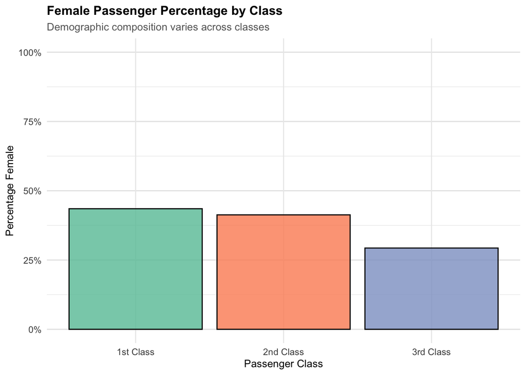

```r
# Visualize gender composition by class
gender_plot <- gender_class %>%
  ggplot(aes(x = class_label, y = pct_female, fill = class_label)) +
  geom_col(alpha = 0.8, color = "black", linewidth = 0.5) +
  scale_y_continuous(labels = function(x) paste0(x, "%"), limits = c(0, 100)) +
  scale_fill_brewer(palette = "Set2", guide = "none") +
  labs(
    title = "Female Passenger Percentage by Class",
    subtitle = "Demographic composition varies across classes",
    x = "Passenger Class",
    y = "Percentage Female"
  ) +
  theme_minimal() +
  theme(
    plot.title = element_text(face = "bold", size = 12),
    plot.subtitle = element_text(size = 10, color = "gray40"),
    axis.title = element_text(size = 10),
    panel.grid.major.y = element_line(color = "gray90")
  )

print(gender_plot)
```

**Narrative:** The bar chart shows that first-class had the largest proportion of female passengers at 43.5%, while third-class had only 29.3%. This demographic difference is relevant because the “women and children first” protocol would mechanically increase the survival rate of classes with more women, independent of whether evacuation access or priority enforcement differed by class. This motivates a stratified analysis where we examine men and women separately.

### 4.2 Age Distribution by Class

```r
# Examine age distribution, handling missing values
age_summary <- train %>%
  filter(!is.na(age)) %>%
  group_by(pclass) %>%
  summarise(
    n_with_age = n(),
    mean_age = mean(age),
    median_age = median(age),
    pct_children = sum(age < 18) / n() * 100,
    .groups = 'drop'
  ) %>%
  mutate(
    class_label = factor(
      pclass,
      levels = 1:3,
      labels = c("1st Class", "2nd Class", "3rd Class")
    )
  )

age_summary |> select(class_label, n_with_age, mean_age, median_age, pct_children) |> kable(digits = 1)
```

| class_label | n_with_age | mean_age | median_age | pct_children |
| --- | --- | --- | --- | --- |
| 1st Class | 186 | 38.2 | 37 | 6.5 |
| 2nd Class | 173 | 29.9 | 29 | 13.3 |
| 3rd Class | 355 | 25.1 | 24 | 22.0 |

```r
# Store age composition statistics
first_class_pct_children <- age_summary$pct_children[1]
third_class_pct_children <- age_summary$pct_children[3]
```

**Narrative:** Age composition also varies across classes, with first-class having 6.5% children (under 18) compared to 22% in third class. Since children were typically prioritized in evacuation alongside women, this compositional difference is another potential explanation for the class-survival gap that we must account for through stratified analysis. The presence of 177 missing age values requires us to note that age-based stratification will be based on complete cases only.